# MTH6139 Time Series

US Accidental Deaths

Mariam Khan

March 2024

# US Accidental Deaths

This project aims to use Meta’s Prophet forecasting system to analyse the time series data of ‘US Accidental Deaths’. The main objective is to identify patterns, trends, and underlying factors, such as environmental, societal, and technological, that influence accidental deaths in the United States over time.

Moreover, the project will use forecasting to predict future trends in accidental deaths. By examining historical data patterns and projecting potential changes, this analysis can help identify areas where accident rates may increase or decrease. Through the study and prediction of future data, valuable insights to inform strategies for accident prevention may be gained.

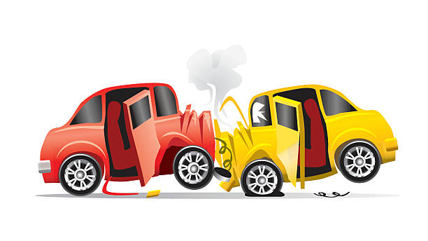

## 1. Load the Library

```r
library(prophet)
```

## 2. Time Series as an R dataframe

I am using the time series “USAccDeaths”, which contains monthly US Accidental Deaths from 1973 to 1978.

```r
data("USAccDeaths")
USAccDeaths
```

```
##        Jan   Feb   Mar   Apr   May   Jun   Jul   Aug   Sep   Oct   Nov   Dec
## 1973  9007  8106  8928  9137 10017 10826 11317 10744  9713  9938  9161  8927
## 1974  7750  6981  8038  8422  8714  9512 10120  9823  8743  9129  8710  8680
## 1975  8162  7306  8124  7870  9387  9556 10093  9620  8285  8466  8160  8034
## 1976  7717  7461  7767  7925  8623  8945 10078  9179  8037  8488  7874  8647
## 1977  7792  6957  7726  8106  8890  9299 10625  9302  8314  8850  8265  8796
## 1978  7836  6892  7791  8192  9115  9434 10484  9827  9110  9070  8633  9240
```

```r
deaths.df = data.frame(ds = zoo::as.yearmon(time(USAccDeaths)), y = USAccDeaths)
```

The time series has been converted into a dataframe with 2 columns:

- ds -> time in months
- y -> number of deaths

The following code checks the first few rows and the structure of the plot:

```r
head(deaths.df)
```

```
##         ds     y
## 1 Jan 1973  9007
## 2 Feb 1973  8106
## 3 Mar 1973  8928
## 4 Apr 1973  9137
## 5 May 1973 10017
## 6 Jun 1973 10826
```

```r
str(deaths.df)
```

```
## 'data.frame':    72 obs. of  2 variables:
##  $ ds: 'yearmon' num  Jan 1973 Feb 1973 Mar 1973 Apr 1973 ...
##  $ y : Time-Series  from 1973 to 1979: 9007 8106 8928 9137 10017 ...
```

## 3. Linear Regression Analysis

It may be beneficial to check if there are any potential linear trends in the dataset. The following code fits a linear trend function to the time series using the lm function.

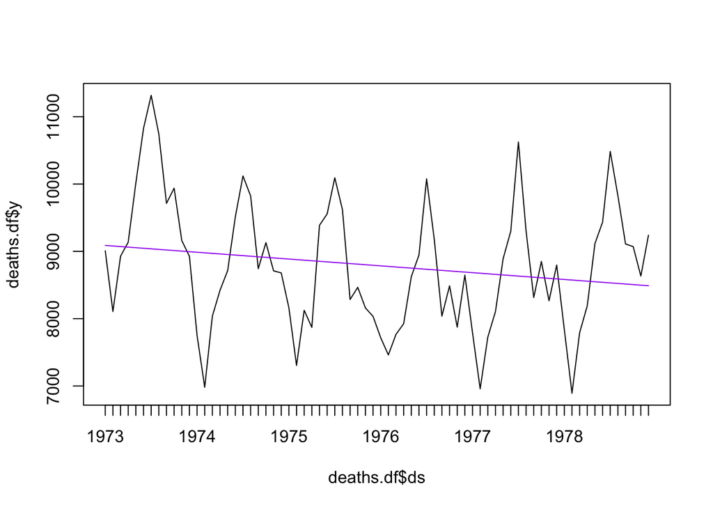

```r
plot(deaths.df$ds, deaths.df$y, type = 'l')
linear_model <- lm(y ~ ds, deaths.df)
lines(deaths.df$ds, fitted(linear_model), type = 'l', col = 'purple')
```

```r
summary(linear_model)
```

```
##
## Call:
## lm(formula = y ~ ds, data = deaths.df)
##
## Residuals:
##     Min      1Q  Median      3Q     Max
## -1997.4  -745.2  -104.4   662.7  2279.6
##
## Coefficients:
##              Estimate Std. Error t value Pr(>|t|)
## (Intercept) 208638.89  127477.33   1.637    0.106
## ds            -101.14      64.51  -1.568    0.121
##
## Residual standard error: 948.1 on 70 degrees of freedom
## Multiple R-squared:  0.03392,    Adjusted R-squared:  0.02012
## F-statistic: 2.458 on 1 and 70 DF,  p-value: 0.1215
```

The plot above displays the time series of accidental deaths, where the x-axis represents time in months and the y-axis represents the number of deaths. The purple line shows the linear regression fitted to the data. Looking at the plot and the summary statistics of the linear regression model, it’s evident that a linear trend does not capture the underlying pattern in the time series data.

## 4. Fit the Prophet Model

The prophet model can now be fitted to the dataframe.

```r
model = prophet(deaths.df)
```

```
## Disabling weekly seasonality. Run prophet with weekly.seasonality=TRUE to override this.
```

```
## Disabling daily seasonality. Run prophet with daily.seasonality=TRUE to override this.
```

## 5. Create Future Dates

To create future dates for forecasting:

```r
future = make_future_dataframe(model, periods = 24, freq = "month")
```

As the frequency of forecasting is set to monthly and there are 24 periods, this creates dates for up to 2 years into the future. (1980)

## 6. The Forecast

Now, the prophet model and the future dates are used to generate forecasts.

First, the predict function needs to be run.

```r
pred = predict(model, future)
```

The forecast can now be displayed along with uncertainty intervals, represented by the shaded areas. The wider the uncertainty interval, the greater the uncertainty in the forecasted values.

```r
dyplot.prophet(model, pred)
```

[interactive chart not shown]

It is also useful to see the forecast broken down into trend and yearly seasonality.

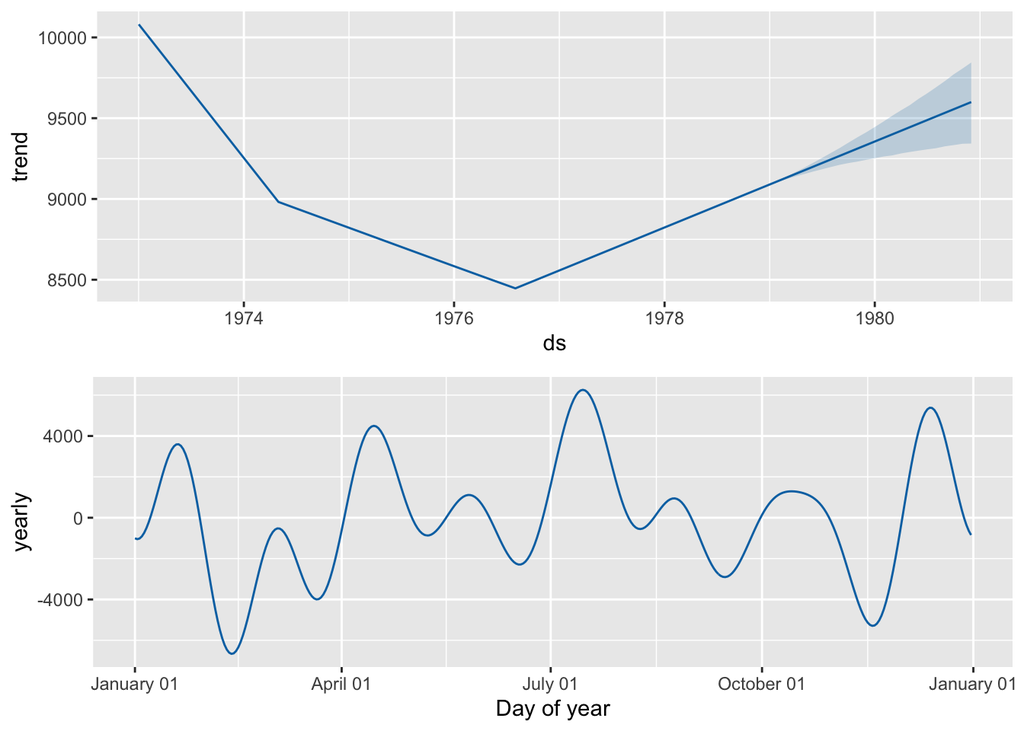

```r
prophet_plot_components(model, pred)
```

The trend component highlights any continuous upward or downward movement over time. Here, it seems to be that accidental deaths were decreasing from 1973 to around mid 1976, and then they started to increase continiously.

The seasonality component reflects the recurring patterns or cycles observed within the data yearly. These patterns are essential to accurately model forecasts, especially in time series with strong seasonal patterns, much like the one this project explores.

We can also consider a larger future forecast, for example 10 or 20 years.

```r
future2 = make_future_dataframe(model, periods = 120, freq = "month")
pred2 = predict(model, future2)
dyplot.prophet(model, pred2)
```

[interactive chart not shown]

```r
future3 = make_future_dataframe(model, periods = 240, freq = "month")
pred3 = predict(model, future3)
dyplot.prophet(model, pred3)
```

[interactive chart not shown]

## 7. Analysis

The data shows a clear seasonal pattern, with peaks occurring regularly, particularly around the summer months. This suggests that accidental deaths tend to rise and fall at specific times of the year. There could be numerous explanations for this.

Firstly, warmer months typically see heightened travel and outdoor activities, resulting in increased exposure to potential accidents. For example, in the summer, drowning incidents rise due to more participation in water-related activities. Moreover, temperature extremes can also increase the risk of deaths from heat stroke.

On the other hand, the troughs in accidental deaths are observed around February each year. This may be due to harsh weather conditions causing decreased outdoor activities and travel, thus reducing the likelihood of accidents. Additionally, during winter months, there is a heightened awareness of safety measures and a larger effort to enforce traffic laws. It may also be due to the simple reason of February being a shorter month.

Notably, the magnitude of peaks and troughs varies from year to year. This implies that there are additional factors, such as economic or societal changes, that have an affect beyond simple seasonality. During economic downturns, for example, rising unemployment rates may result in fewer vehicles on the roads, impacting accident rates. Conversely, periods of economic growth may lead to increased travel and activity, resulting in higher accident rates.

Looking at the graphs with the extended time frames of 10 and 20 years, the peaks in accidental deaths increase over time. This implies a concerning trend, suggesting that despite technological and societal advancements, the number of accidental deaths may rise in the future. However, the light blue shading around the graph, which represents the uncertainty in the data, also expands over time, highlighting the unpredictability of future outcomes.